# Project Report

# 01 Introduction

## 1.1 Motivation

Most of us have experienced waiting at the airport for the delayed flight. As the holiday season approaches, departure on-time have becoming more and more challenging. This year, there are already [more than 4,000 flights delayed](https://www.npr.org/2022/11/27/1139327883/flights-delayed-canceled-holiday-travel-thanksgiving) as holiday travel spikes in the U.S. The flight delay issue especially concerns busy metropolitan airports like JFK.

[figure not shown]

JFK Airport in 2022 holiday season: We can’t stress this enough — plan ahead and arrive early

Source: [Twitter@JFKairport](https://twitter.com/JFKairport/status/1596760846075850752?s=20&t=izIa7AkbJaJ96p0IvvPFVw)

Using JFK departed flights as an example, we’re interested in exploring the factors that are potentially related with flight delay (e.g., airlines, weather, and COVID conditions). By doing so, we’d like to give the holiday travelers a better sense of what to expect regarding flight delay for this holiday season, in order to make better travel plans accordingly.

## 1.2 Related Work

### Common reasons for flight delay

Commercial aviation is a complex distributed transportation system. The typical operation of a commercial flight can take place at terminal boundaries, airports, runways, and airspace, being susceptible to different kinds of delays. Some examples include mechanical problems, weather conditions, ground delays, air traffic control, runway queues and capacity constraints.

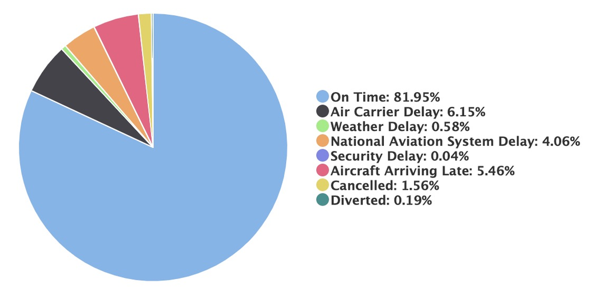

Common reasons for delay in the US, 2022

[Source: transtats.bts.gov](https://www.transtats.bts.gov/OT_Delay/OT_DelayCause1.asp)

### Typical operation of a commercial flight

The following scheme is repeated several times throughout the day for each flight in the system:

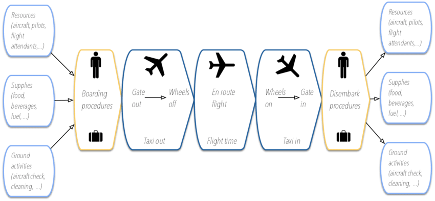

A typical operation of a commercial flight

[Source: Sternberg, et al. (2017). A Review on Flight Delay Prediction.](https://www.researchgate.net/publication/315382748_A_Review_on_Flight_Delay_Prediction)

Pilots, flight attendants and aircrafts may have different schedules due to legal rests, duties, and maintenance plans for airplanes. So, any disruption in the system can impact the subsequent flights of the same airline. Moreover, disturbances may cause congestion at airspace or other airports, creating queues and delaying some flights from other carriers.

## 1.3 Initial Questions

Considering the availability and scale of the flight data, we focus on JFK Airport’s delay and cancellation data from Nov. 1st, 2020 to Jan 31st, 2021. And then find the weather and covid cases data within that time range accordingly. Based on these information, our final questions are below:

- What are the key trends of the flights in JFK during last holiday season?
- What are the potential factors that contribute to the flight delay in JFK during last holiday season?
- Are there significant associations of multiple factors with JFK flight delays during last holiday season?

# 02 Data Source and Cleaning

## 2.1 Data Source

- [Flight delay and cancellation data](https://www.transtats.bts.gov/ONTIME/) - The Bureau of Transportation Statistics (BTS)
- [Weather condition data](https://www.ncdc.noaa.gov/cdo-web/datatools/lcd) - The National Oceanic and Atmospheric Administration (NOAA)
- [COVID data](https://data.cityofnewyork.us/Health/COVID-19-Daily-Counts-of-Cases-Hospitalizations-an/rc75-m7u3) - NYC OpenData
- [Airport location information](https://data.humdata.org/dataset/ourairports-usa) - The Humanitarian Data Exchange

## 2.2 Data Cleaning

# 03 Exploratory Analysis

## 3.1 Visualization

## 3.2 Mapping

# 04 Additional Anslysis

## 4.1 Poisson Regression

## 4.2 Predictive Model (Linear Regression)

# 05 Discussion

## 5.1 Findings

## 5.2 Next Steps